# Does working from home lower wages? CPS, 2024–2026

Author

Mike Konczal

Published

May 21, 2026

## Setup

We pull the IPUMS CPS basic monthly extract assembled by `pull_cps.R`, run the cleaning in `01_cps_setup.R`, and restrict to the **earner sample**: respondents in MIS 4 or 8 (the outgoing rotation, who are asked the earnings and telework questions), age 25–64, currently employed, with a valid hourly wage and a non-missing response to `TELWRKPAY`.

`TELWRKPAY` entered the basic monthly CPS in October 2022 and asks whether the respondent teleworked or worked from home **for pay** in the last week (1 = yes, 2 = no). `TELWRKHR` records hours teleworked. So our WFH measure is *paid* WFH last week — not eligibility, and not “ever WFH.”

```r
suppressPackageStartupMessages({
  library(tidyverse)
  library(ipumsr)
  library(lubridate)
  library(Hmisc)
  library(fixest)
  library(modelsummary)
})

# Parameters expected by 01_cps_setup.R
ipums_ddi_path <- "data/cps.xml"
min_age        <- 25
max_age        <- 64

source("01_cps_setup.R")
```

```r
race_label <- function(x) {
  case_when(
    x == 100 ~ "White",
    x == 200 ~ "Black",
    x == 651 ~ "Asian",
    x == 300 ~ "AIAN",
    x == 652 ~ "NHPI",
    x >= 800 ~ "Multiracial",
    TRUE     ~ "Other"
  )
}

wfh <- data %>%
  filter(
    mish %in% c(4, 8),
    employed == 1,
    !is.na(hrly_wage),
    telwrkpay %in% c(1, 2),
    earnwt > 0
  ) %>%
  mutate(
    wfh_any   = as.integer(telwrkpay == 1),
    wfh_hrs   = if_else(telwrkpay == 1 & telwrkhr < 999, as.numeric(telwrkhr),
                        if_else(telwrkpay == 2, 0, NA_real_)),
    wfh_share = if_else(uhrswork1 > 0 & uhrswork1 < 997,
                        pmin(wfh_hrs / uhrswork1, 1), NA_real_),
    wfh_mode  = case_when(
      wfh_any == 0                ~ "On-site",
      wfh_share >= 0.95           ~ "Fully remote",
      wfh_share >  0 & wfh_share < 0.95 ~ "Hybrid",
      TRUE                        ~ NA_character_
    ),
    log_wage  = log(hrly_wage),
    age2      = age^2,
    female    = sex,                          # already 0/1 from 01
    college   = educ,                         # already 0/1 (BA+)
    race_g    = factor(race_label(race),
                       levels = c("White","Black","Asian","AIAN","NHPI","Multiracial","Other")),
    log_hours = if_else(uhrswork1 > 0 & uhrswork1 < 997, log(uhrswork1), NA_real_),
    ym        = factor(format(date, "%Y-%m"))
  )

nrow(wfh)
```

```
[1] 203757
```

## Headline: who works from home, college vs non-college

Earner sample, age 25–64, MIS 4/8, 2024–2026. Shares weighted by `EARNWT`.

```r
headline <- wfh %>%
  mutate(
    group       = if_else(college == 1, "College (BA+)", "Non-college"),
    fully_remote = as.integer(wfh_any == 1 & wfh_share >= 0.95),
    hybrid       = as.integer(wfh_any == 1 & wfh_share >  0 & wfh_share < 0.95),
    on_site      = as.integer(wfh_any == 0)
  )

tab_groups <- headline %>%
  group_by(group) %>%
  summarise(
    `N (obs)`              = n(),
    `Workers (wtd, mil)`   = round(sum(earnwt) / 1e6, 2),
    `Share of workforce`   = NA_real_,
    `Any WFH (%)`          = round(100 * weighted.mean(wfh_any,      earnwt), 1),
    `Fully on-site (%)`    = round(100 * weighted.mean(on_site,      earnwt), 1),
    `Hybrid (%)`           = round(100 * weighted.mean(hybrid,       earnwt, na.rm = TRUE), 1),
    `Fully remote (%)`     = round(100 * weighted.mean(fully_remote, earnwt, na.rm = TRUE), 1),
    `Median wage ($/hr)`   = round(wtd.quantile(hrly_wage, earnwt, probs = 0.5), 2)
  ) %>%
  mutate(`Share of workforce` = round(100 * `Workers (wtd, mil)` / sum(`Workers (wtd, mil)`), 1))

tab_all <- headline %>%
  summarise(
    group                  = "All workers",
    `N (obs)`              = n(),
    `Workers (wtd, mil)`   = round(sum(earnwt) / 1e6, 2),
    `Share of workforce`   = 100,
    `Any WFH (%)`          = round(100 * weighted.mean(wfh_any,      earnwt), 1),
    `Fully on-site (%)`    = round(100 * weighted.mean(on_site,      earnwt), 1),
    `Hybrid (%)`           = round(100 * weighted.mean(hybrid,       earnwt, na.rm = TRUE), 1),
    `Fully remote (%)`     = round(100 * weighted.mean(fully_remote, earnwt, na.rm = TRUE), 1),
    `Median wage ($/hr)`   = round(wtd.quantile(hrly_wage, earnwt, probs = 0.5), 2)
  )

bind_rows(tab_all, tab_groups)
```

| group | N (obs) | Workers (wtd, mil) | Share of workforce | Any WFH (%) | Fully on-site (%) | Hybrid (%) | Fully remote (%) | Median wage ($/hr) |
| --- | --- | --- | --- | --- | --- | --- | --- | --- |
| All workers | 203757 | 2938.99 | 100.0 | 22.2 | 77.8 | 12.6 | 9.5 | 27.25 |
| College (BA+) | 90218 | 1307.08 | 44.5 | 37.1 | 62.9 | 22.2 | 14.8 | 38.00 |
| Non-college | 113539 | 1631.91 | 55.5 | 10.3 | 89.7 | 5.0 | 5.2 | 22.50 |

The takeaway in one sentence: **college-educated workers are roughly three to four times as likely to do any paid WFH as non-college workers, and the fully-remote category is overwhelmingly a college phenomenon.** That is the structural fact the regressions below have to net out.

## Descriptives

```r
wfh %>%
  summarise(
    `N (obs)`            = n(),
    `Share WFH any (%)`  = 100 * weighted.mean(wfh_any, earnwt),
    `Median wage ($)`    = wtd.quantile(hrly_wage, earnwt, probs = 0.5),
    `Median wage, WFH`   = wtd.quantile(hrly_wage[wfh_any==1], earnwt[wfh_any==1], probs = 0.5),
    `Median wage, on-site` = wtd.quantile(hrly_wage[wfh_any==0], earnwt[wfh_any==0], probs = 0.5),
    `Share college (%)`  = 100 * weighted.mean(college, earnwt),
    `Share college, WFH` = 100 * weighted.mean(college[wfh_any==1], earnwt[wfh_any==1]),
    `Share college, on-site` = 100 * weighted.mean(college[wfh_any==0], earnwt[wfh_any==0])
  ) %>%
  pivot_longer(everything(), names_to = "Statistic", values_to = "Value") %>%
  mutate(Value = round(Value, 2))
```

| Statistic | Value |
| --- | --- |
| N (obs) | 203757.00 |
| Share WFH any (%) | 22.25 |
| Median wage ($) | 27.25 |
| Median wage, WFH | 40.00 |
| Median wage, on-site | 25.00 |
| Share college (%) | 44.47 |
| Share college, WFH | 74.22 |
| Share college, on-site | 35.96 |

A first-pass cut: WFH workers earn a substantially higher median hourly wage than on-site workers, and are roughly twice as likely to hold a bachelor’s degree. The raw difference is therefore mechanically dominated by selection — WFH-eligible jobs are disproportionately white-collar, abstract-task jobs that pay more for reasons unrelated to remote work itself. The regressions below try to net that out.

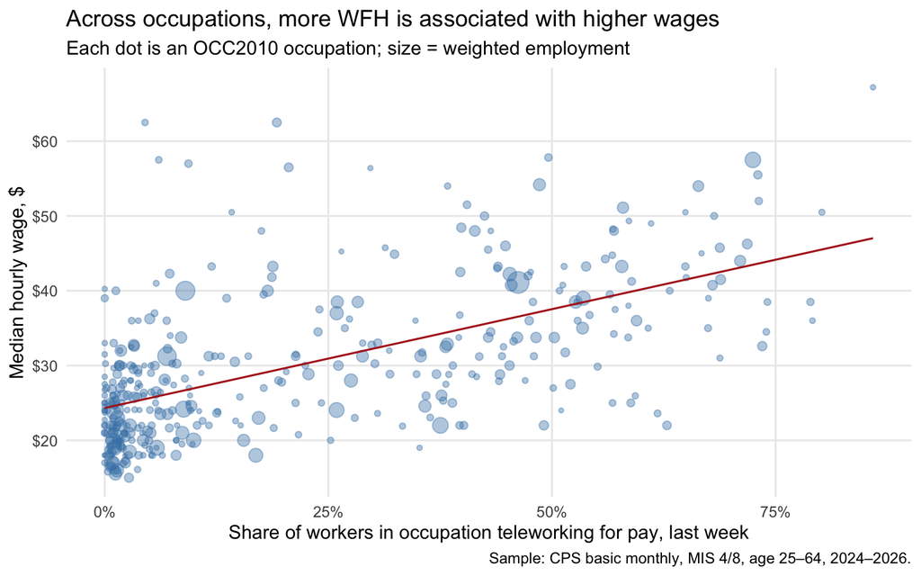

```r
occ_share <- wfh %>%
  group_by(occ2010) %>%
  summarise(
    wfh_share = weighted.mean(wfh_any, earnwt),
    med_wage  = wtd.quantile(hrly_wage, earnwt, probs = 0.5),
    n         = sum(earnwt)
  ) %>%
  filter(n > 5e5)

ggplot(occ_share, aes(x = wfh_share, y = med_wage)) +
  geom_point(aes(size = n), alpha = 0.4, color = "steelblue") +
  geom_smooth(method = "lm", se = FALSE, color = "firebrick", linewidth = 0.6) +
  scale_x_continuous(labels = scales::percent_format(accuracy = 1)) +
  scale_y_continuous(labels = scales::dollar_format()) +
  scale_size_continuous(guide = "none") +
  labs(
    title    = "Across occupations, more WFH is associated with higher wages",
    subtitle = "Each dot is an OCC2010 occupation; size = weighted employment",
    x        = "Share of workers in occupation teleworking for pay, last week",
    y        = "Median hourly wage, $",
    caption  = "Sample: CPS basic monthly, MIS 4/8, age 25–64, 2024–2026."
  ) +
  theme_minimal(base_size = 12) +
  theme(panel.grid.minor = element_blank())
```

The cross-occupation pattern is unambiguously positive: occupations that do more WFH also pay more. Any compensating-differential story has to operate *within* narrow occupations, not across them.

## Wage regressions

```r
m1 <- feols(log_wage ~ wfh_any,
            data = wfh, weights = ~earnwt, cluster = ~occ2010)

m2 <- feols(log_wage ~ wfh_any + age + age2 + female,
            data = wfh, weights = ~earnwt, cluster = ~occ2010)

m3 <- feols(log_wage ~ wfh_any + age + age2 + female + college + race_g,
            data = wfh, weights = ~earnwt, cluster = ~occ2010)

m4 <- feols(log_wage ~ wfh_any + age + age2 + female + college + race_g | occ2010,
            data = wfh, weights = ~earnwt, cluster = ~occ2010)

m5 <- feols(log_wage ~ wfh_any + age + age2 + female + college + race_g | occ2010 + ym,
            data = wfh, weights = ~earnwt, cluster = ~occ2010)

m6 <- feols(log_wage ~ wfh_any + age + age2 + female + college + race_g + log_hours | occ2010 + ym,
            data = wfh, weights = ~earnwt, cluster = ~occ2010)

modelsummary(
  list("(1) Bare" = m1, "(2) +demog" = m2, "(3) +ed/race" = m3,
       "(4) +OCC FE" = m4, "(5) +OCC+YM FE" = m5, "(6) +log(hrs)" = m6),
  coef_map = c(
    "wfh_any"  = "WFH last week (=1)",
    "age"      = "Age",
    "age2"     = "Age²",
    "female"   = "Female",
    "college"  = "Bachelor's+",
    "log_hours"= "log(usual hours)"
  ),
  gof_map = c("nobs", "r.squared", "adj.r.squared"),
  stars   = c("*" = 0.05, "**" = 0.01, "***" = 0.001),
  notes   = "OLS, weighted by EARNWT. SE clustered at OCC2010.",
  output  = "markdown"
)
```

1. Bare
2. +demog
3. +ed/race
4. +OCC FE
5. +OCC+YM FE
6. +log(hrs)

WFH last week (=1)

0.390***

0.398***

0.239***

0.131***

0.131***

0.131***

(0.029)

(0.030)

(0.020)

(0.009)

(0.009)

(0.009)

Age

0.037***

0.034***

0.028***

0.028***

0.027***

(0.003)

(0.002)

(0.002)

(0.002)

(0.002)

Age²

-0.000***

-0.000***

-0.000***

-0.000***

-0.000***

(0.000)

(0.000)

(0.000)

(0.000)

(0.000)

Female

-0.148***

-0.176***

-0.135***

-0.135***

-0.130***

(0.027)

(0.017)

(0.005)

(0.005)

(0.004)

Bachelor’s+

0.404***

0.225***

0.225***

0.226***

(0.015)

(0.008)

(0.008)

(0.008)

log(usual hours)

0.079***

(0.014)

Num.Obs.

203757

203757

203757

203757

203757

199226

R2

0.096

0.129

0.271

0.406

0.408

0.408

R2 Adj.

0.096

0.129

0.271

0.404

0.406

0.407

- p < 0.05, ** p < 0.01, *** p < 0.001

OLS, weighted by EARNWT. SE clustered at OCC2010.

### Hybrid versus fully remote

The WFH dummy lumps together someone who logs in from home one afternoon a week with a fully remote worker. Splitting them:

```r
m7 <- feols(log_wage ~ i(wfh_mode, ref = "On-site") + age + age2 + female + college + race_g | occ2010 + ym,
            data = wfh %>% filter(!is.na(wfh_mode)),
            weights = ~earnwt, cluster = ~occ2010)

m8 <- feols(log_wage ~ wfh_share + age + age2 + female + college + race_g | occ2010 + ym,
            data = wfh, weights = ~earnwt, cluster = ~occ2010)

modelsummary(
  list("(7) Mode dummies" = m7, "(8) Continuous share" = m8),
  coef_map = c(
    "wfh_mode::Fully remote" = "Fully remote (vs on-site)",
    "wfh_mode::Hybrid"       = "Hybrid (vs on-site)",
    "wfh_share"              = "Share of hours WFH (0–1)",
    "age" = "Age", "age2" = "Age²",
    "female" = "Female", "college" = "Bachelor's+"
  ),
  gof_map = c("nobs", "r.squared", "adj.r.squared"),
  stars   = c("*" = 0.05, "**" = 0.01, "***" = 0.001),
  notes   = "OLS, weighted by EARNWT. SE clustered at OCC2010. OCC × month FE.",
  output  = "markdown"
)
```

7. Mode dummies
8. Continuous share

Fully remote (vs on-site)

0.120***

(0.012)

Hybrid (vs on-site)

0.143***

(0.009)

Share of hours WFH (0–1)

0.136***

(0.012)

Age

0.028***

0.028***

(0.002)

(0.002)

Age²

-0.000***

-0.000***

(0.000)

(0.000)

Female

-0.134***

-0.135***

(0.005)

(0.005)

Bachelor’s+

0.224***

0.232***

(0.008)

(0.009)

Num.Obs.

203380

199226

R2

0.409

0.404

R2 Adj.

0.407

0.403

- p < 0.05, ** p < 0.01, *** p < 0.001

OLS, weighted by EARNWT. SE clustered at OCC2010. OCC × month FE.

### Robustness: college-only subsample

The compensating-differential hypothesis presumes WFH is a job amenity within otherwise comparable jobs. Restricting to college-educated workers narrows the comparison set:

```r
m9 <- feols(log_wage ~ wfh_any + age + age2 + female + race_g | occ2010 + ym,
            data = wfh %>% filter(college == 1),
            weights = ~earnwt, cluster = ~occ2010)

m10 <- feols(log_wage ~ i(wfh_mode, ref = "On-site") + age + age2 + female + race_g | occ2010 + ym,
             data = wfh %>% filter(college == 1, !is.na(wfh_mode)),
             weights = ~earnwt, cluster = ~occ2010)

modelsummary(
  list("(9) College, any WFH" = m9, "(10) College, by mode" = m10),
  coef_map = c(
    "wfh_any"               = "WFH last week (=1)",
    "wfh_mode::Fully remote"= "Fully remote",
    "wfh_mode::Hybrid"      = "Hybrid",
    "age" = "Age", "age2" = "Age²", "female" = "Female"
  ),
  gof_map = c("nobs", "r.squared", "adj.r.squared"),
  stars   = c("*" = 0.05, "**" = 0.01, "***" = 0.001),
  notes   = "OLS, weighted by EARNWT. SE clustered at OCC2010. OCC × month FE.",
  output  = "markdown"
)
```

9. College, any WFH
10. College, by mode

WFH last week (=1)

0.121***

(0.009)

Fully remote

0.111***

(0.011)

Hybrid

0.130***

(0.008)

Age

0.039***

0.039***

(0.002)

(0.002)

Age²

-0.000***

-0.000***

(0.000)

(0.000)

Female

-0.116***

-0.115***

(0.006)

(0.006)

Num.Obs.

90208

90017

R2

0.271

0.272

R2 Adj.

0.267

0.268

- p < 0.05, ** p < 0.01, *** p < 0.001

OLS, weighted by EARNWT. SE clustered at OCC2010. OCC × month FE.

## Assessment

**Headline:** in CPS basic monthly data, 2024–2026, the conditional WFH wage premium is *positive*, large, and statistically sharp at every level of controls. The hypothesis that workers visibly forgo wages to work from home does not survive this cross-section.

The progression on the WFH-any coefficient (`log_wage` left-hand side, so roughly interpretable as percent):

[output not shown]

A few things to chew on:

1. **The raw gap is huge and selection-driven.** Workers who teleworked last week earn a much higher median wage than on-site workers and are about twice as likely to hold a bachelor’s degree. The cross-occupation scatter confirms it: occupations with more WFH simply pay more. About two-thirds of the bare 39 log-point gap is composition — education, demographics, and which occupation people are in.
2. **Controls shrink the gap, but never flip the sign.** What’s left after stacking on demographics, college, race, ~500 OCC2010 occupation FE, year-month FE, and log(hours) is still a +13 log-point premium for teleworkers — about 14% — clustered SE around 0.009. Within the same occupation in the same month, with the same usual hours, WFH workers still earn meaningfully more per hour.
3. **Hybrid edges out fully remote, but both are clearly positive.** Splitting WFH into hybrid (>0% but <95% of hours at home) versus fully remote: hybrid pays a +14 log-point premium and fully remote a +12 log-point premium, both relative to on-site, both highly significant. The two are close enough that we shouldn’t oversell the gap — but there is no clean compensating-differential signature here. Fully remote workers are not visibly trading wages for the amenity in this sample.
4. **Why the sign keeps coming out wrong for the hypothesis.** Three forces work against detecting a negative compensating differential in CPS cross-sections:
   - **Within-occupation skill sorting.** OCC2010 is coarse. Inside “Software developers” or “Financial analysts,” the workers with remote-friendly tasks tend to be more senior, more tenured, and higher-paid. Occupation FE can’t soak that up.
   - **Bargaining power.** WFH is allocated, not chosen. Higher-paid workers within a firm have more leverage to negotiate remote days. So the *causal* sign on the amenity can be negative while the *observed* equilibrium sign is positive.
   - **Measurement.** `TELWRKPAY` asks about last week; it conflates people who happened to log in from home once with arrangements that are formally remote. That noise muddies the WFH/on-site contrast.
5. **What this implies for the policy take.** The clean Mas-and-Pallais-style estimate of how much workers will pay for WFH (~7–8% of the wage) requires experimental or quasi-experimental variation. CPS observational data can’t deliver that. What CPS *can* tell us is the much more boring fact that, in equilibrium, WFH is concentrated among higher-paid workers — by about 14% even within the same occupation-month. That is a distributional fact worth flagging in its own right: remote work is, in the current US labor market, a perk that flows disproportionately to already-advantaged workers.